# Data Analysis on Iris Dataset

SIBDS @ Columbia

13 June, 2023

```r
data(iris)
```

## Introduction

The iris dataset is a famous dataset in the field of statistics and machine learning. It contains measurements of various features of iris flowers, such as sepal length, sepal width, petal length, and petal width. The goal of this data analysis is to explore the dataset and gain insights into the characteristics of the different iris flower species.

## Exploratory Data Analysis

```r
# View the first few rows of the dataset
head(iris)
```

```
##   Sepal.Length Sepal.Width Petal.Length Petal.Width Species
## 1          5.1         3.5          1.4         0.2  setosa
## 2          4.9         3.0          1.4         0.2  setosa
## 3          4.7         3.2          1.3         0.2  setosa
## 4          4.6         3.1          1.5         0.2  setosa
## 5          5.0         3.6          1.4         0.2  setosa
## 6          5.4         3.9          1.7         0.4  setosa
```

```r
# Summary statistics
summary(iris)
```

```
##   Sepal.Length    Sepal.Width     Petal.Length    Petal.Width
##  Min.   :4.300   Min.   :2.000   Min.   :1.000   Min.   :0.100
##  1st Qu.:5.100   1st Qu.:2.800   1st Qu.:1.600   1st Qu.:0.300
##  Median :5.800   Median :3.000   Median :4.350   Median :1.300
##  Mean   :5.843   Mean   :3.057   Mean   :3.758   Mean   :1.199
##  3rd Qu.:6.400   3rd Qu.:3.300   3rd Qu.:5.100   3rd Qu.:1.800
##  Max.   :7.900   Max.   :4.400   Max.   :6.900   Max.   :2.500
##        Species
##  setosa    :50
##  versicolor:50
##  virginica :50
##
##
##
```

```r
gtsummary::tbl_summary(iris)
```

| **Characteristic** | **N = 150**<sup>1</sup> |
| --- | --- |
| Sepal.Length | 5.80 (5.10, 6.40) |
| Sepal.Width | 3.00 (2.80, 3.30) |
| Petal.Length | 4.35 (1.60, 5.10) |
| Petal.Width | 1.30 (0.30, 1.80) |
| Species |  |
| setosa | 50 (33%) |
| versicolor | 50 (33%) |
| virginica | 50 (33%) |

<sup>1</sup> Median (IQR); n (%)

## Data Visualization

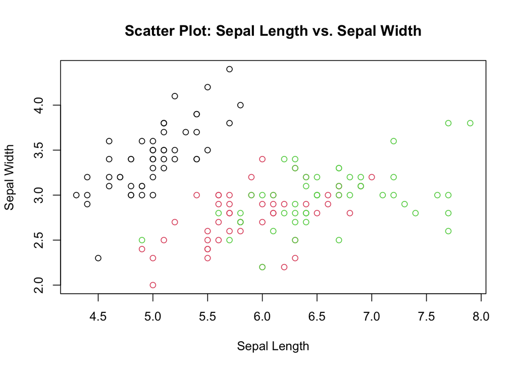

```r
# Scatter plot of sepal length vs. sepal width
plot(iris$Sepal.Length, iris$Sepal.Width, main = "Scatter Plot: Sepal Length vs. Sepal Width",
     xlab = "Sepal Length", ylab = "Sepal Width", col = iris$Species)
```

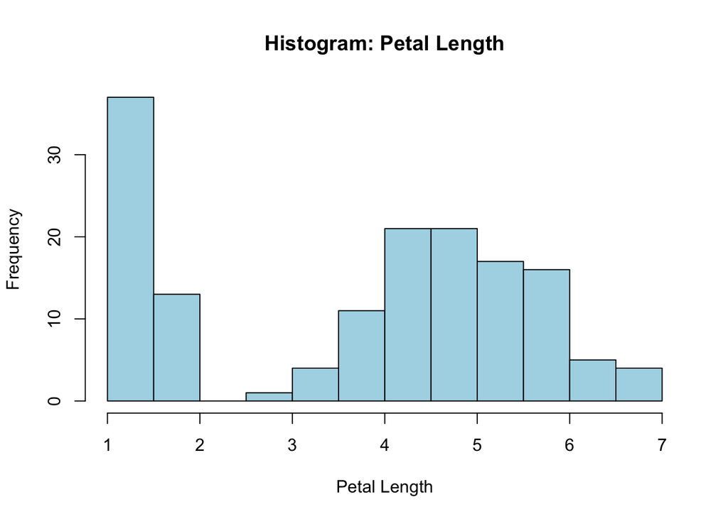

```r
# Histogram of petal length
hist(iris$Petal.Length, main = "Histogram: Petal Length",
     xlab = "Petal Length", ylab = "Frequency", col = "lightblue")
```

## Conclusion

The iris dataset provides valuable insights into the characteristics of different iris flower species. Here is a summary of the analysis:

- The dataset consists of 150 observations and 5 variables.
- The sepal length ranges from 4.3 to 7.9, with a mean of 5.84.
- The sepal width ranges from 2.0 to 4.4, with a mean of 3.05.
- The petal length ranges from 1.0 to 6.9, with a mean of 3.76.
- The petal width ranges from 0.1 to 2.5, with a mean of 1.20. In summary, the exploratory data analysis revealed interesting patterns and distributions among the iris flower species. Further analysis and modeling can be performed on this dataset to address specific research questions or build predictive models.

This concludes the basic data analysis on the iris dataset.